# Metabolic profiling of prostate cancer biopsies using HR-MAS

Jinny Sun

1/29/2018

# Introduction

Prostate cancer is the most commonly diagnosed non-cutaneous cancer in men and the second leading cause of cancer death. Due to over-diagnosis and over-treatment of indolent low-risk disease, active surveillance (AS) involving serial measurements of serum prostate-specific antigen (PSA) and biopsies as well as multiparametric MRI has been implemented in the clinic to monitor disease progression and reduce rates of over-treatment. A pressing need in the clinical management of patients with prostate cancer at the time of diagnosis is an accurate method for distinguishing aggressive, potentially lethal prostate cancer from indolent disease in individual patients in order to assess whether active surveillance is appropriate or aggressive treatment is needed.

The goal of this analysis is to identify metabolic biomarkers of prostate cancer using 1D 1H HR-MAS spectroscopy of fresh prostate tissue specimen. This analysis has significant clinical impact by informing doctors which patients should remain under active surveillance or undergo treatment.

# Experiment Details

1D 1H CPMG spectra was acquired from fresh prostate cancer biopsies using high-resolution magic angle spinning (HR-MAS) NMR. After the experiment, biopsies were formalin-fixed and paraffin embedded for pathologic analysis. Experimental methods can be found in the following publications:

Swanson, Mark G., et al. “Proton HR‐MAS spectroscopy and quantitative pathologic analysis of MRI/3D‐MRSI‐targeted postsurgical prostate tissues.” Magnetic Resonance in Medicine: An Official Journal of the International Society for Magnetic Resonance in Medicine 50.5 (2003): 944-954. [Pubmed](https://www.ncbi.nlm.nih.gov/pubmed/14587005)

Tessem, May-Britt et al. “Evaluation of lactate and alanine as metabolic biomarkers of prostate cancer using 1H HR-MAS spectroscopy of biopsy tissues.” Magnetic resonance in medicine vol. 60,3 (2008): 510-6. [Pubmed](https://www.ncbi.nlm.nih.gov/pmc/articles/PMC2613807/)

# Analysis - Benign vs Cancer

For this analysis, we will identify metabolic biomarkers of prostate cancer by comparing the metabolic profile between benign and cancer in patients that have received no treatment. The aggressiveness of prostate cancer is determined by a Gleason grade, which grades the primary and secondary lesion. The two scores are then added together to A Gleason score. A Gleason score less than 6 is considered “benign”, 6 is considered “low grade cancer”, 7 is considered “imtermediate grade”, and a score of 8 and above is considered “high grade”. Clinically, patients with a Gleason score of 6 or under should remain under active surveillance, and patients with a Gleason score of 7 or higher should undergo treatment.

## Load data

The data is presented in csv format.

```r
data = read.csv("ProstateHrmas.csv", header = T, stringsAsFactors = FALSE, fill = T)
```

## Load libraries

Load the libraries required for this analysis.

```r
library(tidyverse)
library(reshape2)
library(RColorBrewer)

library(lattice)
library(corrplot)
library(class)
library(boot)
```

## Clean data

This dataset of consists of 287 tissue samples (biopsies, post-surgical tissues, and primary cell culture) and 32 features, including information on the patient history, 6 parameters pertaining to HR-MAS spectroscopy, histopathology, and 19 metabolite concentrations. Here, we are interested in some of the features pertaining to patient history, histopathology, and metabolite concentrations. Features that we are not interested in are removed using `select`. This analysis will focus on comparing the metabolite concentrations of fresh tissue samples, namely biopsies (BY) and post-surgical tissues (P), from patients who have not received treatment. Use `filter` to remove cell culture (CC) tissue samples.

```r
dim(data)
```

```
## [1] 287  32
```

```r
data
```

| ID | treatment | treatment_type | tissue_mass | spin_rate | exp_duration | echo_time | mixing_time | h1_90deg_pw | glandular_normal | stroma_normal | cancer | gleason_grade | PC1D | GPC1D | Ethanolamin1D | PE1D | Lactate1D | Alanine1D | Choline1D | Citrate1D | mInositol1D | sInositol1D | PCr1D | Cr1D | Glutamate1D | Glutamine1D | Glycine1D | Spermidine1D | Spermine1D | … |
| --- | --- | --- | --- | --- | --- | --- | --- | --- | --- | --- | --- | --- | --- | --- | --- | --- | --- | --- | --- | --- | --- | --- | --- | --- | --- | --- | --- | --- | --- | --- |
| BY252 | Radiation | Brachytherapy PPI | 5.98 | 2250 | NA | 144 | 40 | 8.15 | 11% | 88% | 0% | Benign | 0.161 | 0.094 | 0.405 | 0.844 | 1.081 | 0.179 | 0.062 | 0.193 | 1.885 | 0.000 | NA | 0.638 | 1.198 | 0.325 | 1.785 | 0.000 | 0.005 | … |
| BY253 | None | No Treatment | 5.69 | 2250 | 162 | 144 | 40 | 7.55 | 8% | 55% | 5% | G3+3 | 0.848 | 0.172 | 0.697 | 1.299 | 1.434 | 0.793 | 0.153 | 0.518 | 3.238 | 0.222 | NA | 0.390 | 2.858 | 0.731 | 2.993 | 0.000 | 0.000 | … |
| BY259 | None | No Treatment | 6.44 | 2250 | NA | 144 | 40 | NA | 33% | 66% | 0% | Benign | 0.262 | 0.390 | 0.362 | 1.235 | 0.864 | 0.410 | 0.147 | 5.517 | 4.040 | 0.524 | NA | 0.588 | 2.081 | 0.563 | 1.183 | 0.783 | 0.452 | … |
| BY260 | None | No Treatment | 7.40 | 2250 | 130 | 144 | 40 | NA | 35% | 65% | 0% | Benign | 0.176 | 0.241 | 0.445 | 0.753 | 0.546 | 0.263 | 0.219 | 4.039 | 2.527 | 0.325 | NA | 0.432 | 1.517 | 0.489 | 0.662 | 0.536 | 0.516 | … |
| BY261 | None | No Treatment | 7.58 | 2250 | 145 | 288 | 40 | 7.85 | 6% | 75% | 18% | G3+3 | 0.001 | 0.588 | 0.283 | 1.029 | 19.029 | 0.621 | 0.159 | 2.513 | 4.590 | 0.045 | NA | 0.290 | 1.973 | 5.761 | 1.900 | 0.877 | 0.428 | … |
| BY262 | None | No Treatment | 7.01 | 2250 | 116 | 144 | 40 | NA | 5% | 85% | 0% | Benign | 0.193 | 0.060 | 0.000 | 0.670 | 0.401 | 0.207 | 0.073 | 0.144 | 2.665 | 0.056 | NA | 0.401 | 1.434 | 0.347 | 0.815 | 0.000 | 0.000 | … |
| BY265 | None | No Treatment | 7.04 | 2250 | 179 | 144 | 40 | NA | 11% | 88% | 0% | Benign | 0.471 | 0.336 | 0.000 | 1.436 | 1.752 | 0.218 | 0.216 | 1.893 | 3.852 | 0.208 | NA | 1.003 | 1.895 | 0.250 | 2.799 | 0.186 | 0.056 | … |
| BY266 | None | No Treatment | 4.15 | 2250 | 86 | 144 | NA | NA | 35% | 65% | 0% | Benign | 0.191 | 0.329 | 0.257 | 1.221 | 0.927 | 0.295 | 0.271 | 5.093 | 3.343 | 0.178 | NA | 0.832 | 1.651 | 0.433 | 2.178 | 0.380 | 0.392 | … |
| BY267 | None | No Treatment | 4.99 | 2250 | 157 | 288 | 40 | NA | 8% | 53% | 28% | G4+4 | 0.333 | 0.212 | 0.004 | 1.912 | 1.685 | 0.973 | 0.288 | 2.355 | 0.625 | 0.115 | NA | 0.640 | 2.485 | 0.360 | 1.815 | 0.084 | 0.287 | … |
| BY269 | Radiation | EBRT | 6.36 | 2250 | 140 | 288 | 40 | NA | 12% | 87% | 0% | Benign | 0.092 | 0.145 | NA | 0.406 | 0.902 | NA | 0.037 | 1.190 | 1.393 | NA | NA | NA | 0.571 | NA | 2.721 | NA | NA | … |

[output cut: 277 more lines]

```r
data.2 <- select(data, -(treatment_type:stroma_normal))
data.2
```

| ID | treatment | cancer | gleason_grade | PC1D | GPC1D | Ethanolamin1D | PE1D | Lactate1D | Alanine1D | Choline1D | Citrate1D | mInositol1D | sInositol1D | PCr1D | Cr1D | Glutamate1D | Glutamine1D | Glycine1D | Spermidine1D | Spermine1D | Taurine1D | Glutathione1D |
| --- | --- | --- | --- | --- | --- | --- | --- | --- | --- | --- | --- | --- | --- | --- | --- | --- | --- | --- | --- | --- | --- | --- |
| BY252 | Radiation | 0% | Benign | 0.161 | 0.094 | 0.405 | 0.844 | 1.081 | 0.179 | 0.062 | 0.193 | 1.885 | 0.000 | NA | 0.638 | 1.198 | 0.325 | 1.785 | 0.000 | 0.005 | 1.856 | NA |
| BY253 | None | 5% | G3+3 | 0.848 | 0.172 | 0.697 | 1.299 | 1.434 | 0.793 | 0.153 | 0.518 | 3.238 | 0.222 | NA | 0.390 | 2.858 | 0.731 | 2.993 | 0.000 | 0.000 | 3.244 | NA |
| BY259 | None | 0% | Benign | 0.262 | 0.390 | 0.362 | 1.235 | 0.864 | 0.410 | 0.147 | 5.517 | 4.040 | 0.524 | NA | 0.588 | 2.081 | 0.563 | 1.183 | 0.783 | 0.452 | 3.093 | NA |
| BY260 | None | 0% | Benign | 0.176 | 0.241 | 0.445 | 0.753 | 0.546 | 0.263 | 0.219 | 4.039 | 2.527 | 0.325 | NA | 0.432 | 1.517 | 0.489 | 0.662 | 0.536 | 0.516 | 2.096 | NA |
| BY261 | None | 18% | G3+3 | 0.001 | 0.588 | 0.283 | 1.029 | 19.029 | 0.621 | 0.159 | 2.513 | 4.590 | 0.045 | NA | 0.290 | 1.973 | 5.761 | 1.900 | 0.877 | 0.428 | 2.584 | NA |
| BY262 | None | 0% | Benign | 0.193 | 0.060 | 0.000 | 0.670 | 0.401 | 0.207 | 0.073 | 0.144 | 2.665 | 0.056 | NA | 0.401 | 1.434 | 0.347 | 0.815 | 0.000 | 0.000 | 1.653 | NA |
| BY265 | None | 0% | Benign | 0.471 | 0.336 | 0.000 | 1.436 | 1.752 | 0.218 | 0.216 | 1.893 | 3.852 | 0.208 | NA | 1.003 | 1.895 | 0.250 | 2.799 | 0.186 | 0.056 | 4.676 | NA |
| BY266 | None | 0% | Benign | 0.191 | 0.329 | 0.257 | 1.221 | 0.927 | 0.295 | 0.271 | 5.093 | 3.343 | 0.178 | NA | 0.832 | 1.651 | 0.433 | 2.178 | 0.380 | 0.392 | 2.780 | NA |
| BY267 | None | 28% | G4+4 | 0.333 | 0.212 | 0.004 | 1.912 | 1.685 | 0.973 | 0.288 | 2.355 | 0.625 | 0.115 | NA | 0.640 | 2.485 | 0.360 | 1.815 | 0.084 | 0.287 | 1.784 | NA |
| BY269 | Radiation | 0% | Benign | 0.092 | 0.145 | NA | 0.406 | 0.902 | NA | 0.037 | 1.190 | 1.393 | NA | NA | NA | 0.571 | NA | 2.721 | NA | NA | 0.661 | NA |

[output cut: 277 more lines]

```r
data.nt <- filter (data.2, treatment == "None", !grepl("*CC",ID))
dim(data.nt)
```

```
## [1] 200  23
```

```r
data.nt
```

| ID | treatment | cancer | gleason_grade | PC1D | GPC1D | Ethanolamin1D | PE1D | Lactate1D | Alanine1D | Choline1D | Citrate1D | mInositol1D | sInositol1D | PCr1D | Cr1D | Glutamate1D | Glutamine1D | Glycine1D | Spermidine1D | Spermine1D | Taurine1D | Glutathione1D |
| --- | --- | --- | --- | --- | --- | --- | --- | --- | --- | --- | --- | --- | --- | --- | --- | --- | --- | --- | --- | --- | --- | --- |
| BY253 | None | 5% | G3+3 | 0.848 | 0.172 | 0.697 | 1.299 | 1.434 | 0.793 | 0.153 | 0.518 | 3.238 | 0.222 | NA | 0.390 | 2.858 | 0.731 | 2.993 | 0.000 | 0.000 | 3.244 | NA |
| BY259 | None | 0% | Benign | 0.262 | 0.390 | 0.362 | 1.235 | 0.864 | 0.410 | 0.147 | 5.517 | 4.040 | 0.524 | NA | 0.588 | 2.081 | 0.563 | 1.183 | 0.783 | 0.452 | 3.093 | NA |
| BY260 | None | 0% | Benign | 0.176 | 0.241 | 0.445 | 0.753 | 0.546 | 0.263 | 0.219 | 4.039 | 2.527 | 0.325 | NA | 0.432 | 1.517 | 0.489 | 0.662 | 0.536 | 0.516 | 2.096 | NA |
| BY261 | None | 18% | G3+3 | 0.001 | 0.588 | 0.283 | 1.029 | 19.029 | 0.621 | 0.159 | 2.513 | 4.590 | 0.045 | NA | 0.290 | 1.973 | 5.761 | 1.900 | 0.877 | 0.428 | 2.584 | NA |
| BY262 | None | 0% | Benign | 0.193 | 0.060 | 0.000 | 0.670 | 0.401 | 0.207 | 0.073 | 0.144 | 2.665 | 0.056 | NA | 0.401 | 1.434 | 0.347 | 0.815 | 0.000 | 0.000 | 1.653 | NA |
| BY265 | None | 0% | Benign | 0.471 | 0.336 | 0.000 | 1.436 | 1.752 | 0.218 | 0.216 | 1.893 | 3.852 | 0.208 | NA | 1.003 | 1.895 | 0.250 | 2.799 | 0.186 | 0.056 | 4.676 | NA |
| BY266 | None | 0% | Benign | 0.191 | 0.329 | 0.257 | 1.221 | 0.927 | 0.295 | 0.271 | 5.093 | 3.343 | 0.178 | NA | 0.832 | 1.651 | 0.433 | 2.178 | 0.380 | 0.392 | 2.780 | NA |
| BY267 | None | 28% | G4+4 | 0.333 | 0.212 | 0.004 | 1.912 | 1.685 | 0.973 | 0.288 | 2.355 | 0.625 | 0.115 | NA | 0.640 | 2.485 | 0.360 | 1.815 | 0.084 | 0.287 | 1.784 | NA |
| BY272 | None | 0% | Benign | 0.000 | 0.196 | 0.866 | 0.937 | 1.599 | 0.203 | 0.079 | 4.650 | 1.850 | 0.058 | NA | 0.310 | 1.460 | 0.416 | 6.675 | 0.610 | 0.447 | 0.000 | NA |
| BY274 | None | 0% | Benign | 0.121 | 0.000 | 0.868 | 0.978 | 0.406 | 0.318 | 0.086 | 2.669 | 2.009 | 0.110 | NA | 0.590 | 1.805 | 1.012 | 1.703 | 0.332 | 0.116 | 1.138 | NA |

[output cut: 190 more lines]

To get an idea of the overall distribution of metabolite concentrations, let’s plot the metabolite concentrations for all samples. To plot all of the metabolite concentrations in one graph, we will first use `melt` to condense the data matrix into a single column. Then, use `grep` to select the columns related to metabolite concentrations. To visualize the data, use `ggplot` to create a boxplot overlayed with a scatterplot of all of the metabolite concentrations. To identify outliers, data points are colored based on the gleason score (ie. benign vs cancer) and labeled with individual biospy IDs.

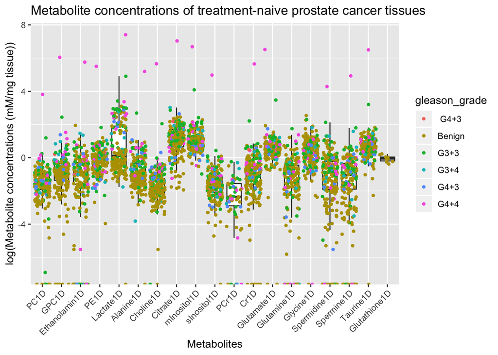

```r
# Melt matrix to plot using ggplot
data.nt.melt <- melt(data.nt)
data.nt.metabolites <- data.nt.melt[grep("*1D", data.nt.melt$variable), ]

# Plot
metabolites.plot <- ggplot(data.nt.metabolites, aes (x = variable, y = log(value)))+
  geom_boxplot( , outlier.shape = NA)+
  geom_jitter(aes(color = gleason_grade), size = 1)+
  theme (axis.text.x = element_text(angle = 45, hjust = 1)) +
  ggtitle("Metabolite concentrations of treatment-naive prostate cancer tissues") +
  xlab("Metabolites") +
  ylab("log(Metabolite concentrations (mM/mg tissue))")

# plot without sample labels
metabolites.plot
```

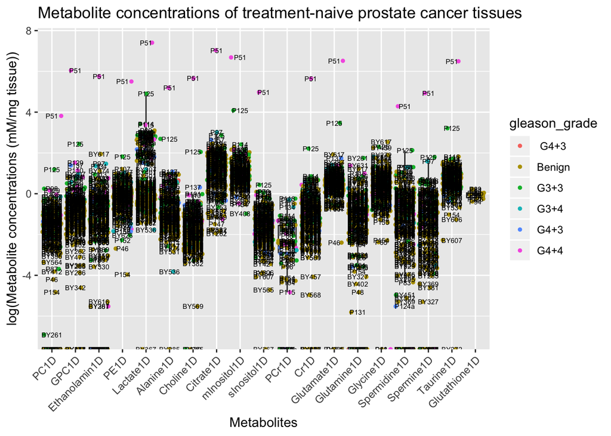

```r
# plot with sample labels
metabolites.plot +
  geom_text(aes(label = ID), size = 2)
```

There are two samples, P51 and P125, that have outliers in several different metabolites, hinting that this is due to experimental error. We will have to remove these from the dataset before any statistical tests are performed. The outlier samples identified in the previous graph are removed using the following code:

```r
data.nt.c <- filter (data.nt, !grepl("P51",ID), !grepl("P125",ID))
```

```r
# Count the number of NA values per column
na_count <-sapply(data.nt.c, function(y) sum(length(which(is.na(y)))))
na_count <- data.frame(na_count)
na_count
```

|  | na_count |
| --- | --- |
| ID | 0 |
| treatment | 0 |
| cancer | 0 |
| gleason_grade | 0 |
| PC1D | 0 |
| GPC1D | 0 |
| Ethanolamin1D | 3 |
| PE1D | 0 |
| Lactate1D | 0 |
| Alanine1D | 3 |

[output cut: 13 more lines]

```r
# Remove columns by name using dplyr
data.nt.c <- select(data.nt.c, -PCr1D, -Glutathione1D)

# Identify samples with NA values
data.nt.c[is.na(data.nt.c$Alanine1D),]
```

|  | ID | treatment | cancer | gleason_grade | PC1D | GPC1D | Ethanolamin1D | PE1D | Lactate1D | Alanine1D | Choline1D | Citrate1D | mInositol1D | sInositol1D | Cr1D | Glutamate1D | Glutamine1D | Glycine1D | Spermidine1D | Spermine1D | Taurine1D |
| --- | --- | --- | --- | --- | --- | --- | --- | --- | --- | --- | --- | --- | --- | --- | --- | --- | --- | --- | --- | --- | --- |
| 51 | BY331 | None | 0% | Benign | 0.306 | 0.272 | NA | 0.995 | 0.677 | NA | 0.065 | 2.713 | 2.274 | NA | NA | 1.777 | NA | 0.972 | NA | NA | 1.918 |
| 52 | BY332 | None | 0% | Benign | 0.221 | 0.230 | NA | 0.689 | 0.301 | NA | 0.043 | 2.851 | 1.533 | NA | NA | 1.061 | NA | 0.601 | NA | NA | 1.525 |
| 68 | BY382 | None | 0% | Benign | 0.302 | 0.160 | NA | 1.010 | 0.429 | NA | 0.033 | 0.172 | 2.296 | 0.198 | 0.604 | 1.098 | NA | 1.772 | NA | NA | 2.047 |

```r
# Remove samples
data.nt.c <- filter (data.nt.c, !grepl("BY331",ID), !grepl("BY332",ID), !grepl("BY382",ID))

#melt matrix and select columns related to metabolite concentrations
data.nt.c.melt <- melt(data.nt.c)
```

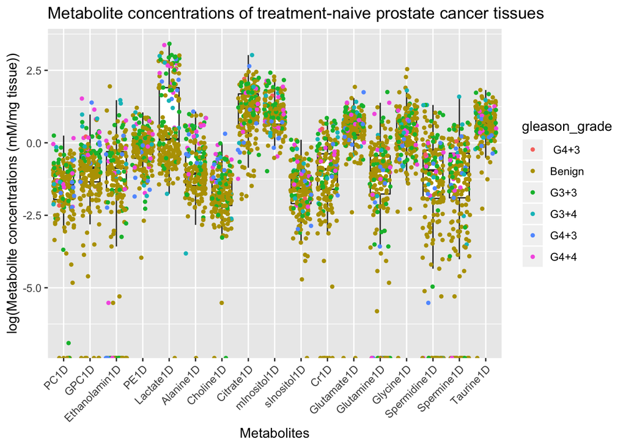

```r
data.nt.c.metabolites <- data.nt.c.melt[grep("*1D", data.nt.c.melt$variable), ]

#plot
ggplot(data.nt.c.metabolites, aes (x = variable, y = log(value))) +
  geom_boxplot( , outlier.shape = NA) +
  geom_jitter(aes(color = gleason_grade), size = 1) +
  theme (axis.text.x = element_text(angle = 45, hjust = 1)) +
  ggtitle("Metabolite concentrations of treatment-naive prostate cancer tissues") +
  xlab("Metabolites") +
  ylab("log(Metabolite concentrations (mM/mg tissue))")
```

For this analysis, we want to compare biopsy tissues that are benign (Gleason score < 6) and cancerous (Gleason score ≥ 6). Let’s plot a histogram of the samples, sorted by gleason grade, to understand the distribution of the data.

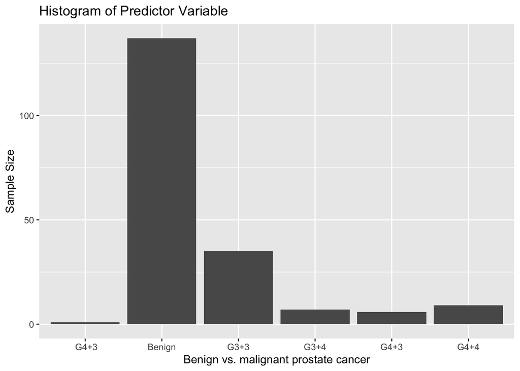

```r
hist <- ggplot(data.frame(data.nt.c), aes(x=gleason_grade)) +
  geom_bar()

hist + ggtitle("Histogram of Predictor Variable") +
  xlab("Benign vs. malignant prostate cancer") + ylab("Sample Size")
```

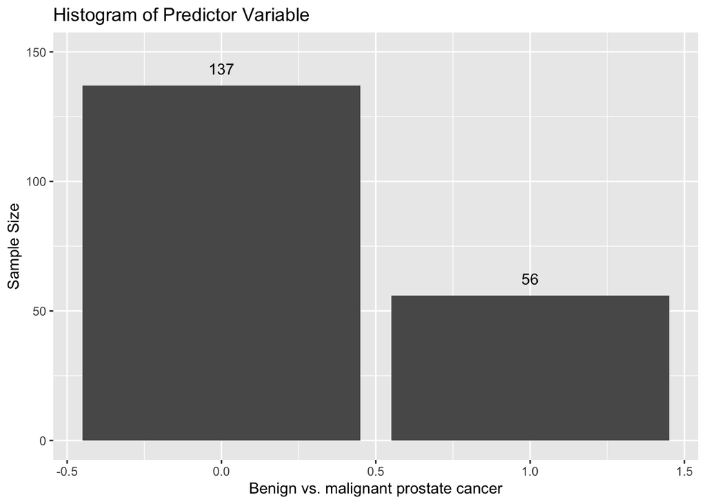

```r
# remove whitespace
data.nt.c$gleason_grade <- str_trim(data.nt.c$gleason_grade, side = c("both"))

# combine G3+3 sample with benign samples.
data.nt.c <- data.nt.c %>% mutate (class = str_replace_all(gleason_grade, "G3\\+3", "Benign"))
data.nt.c <- data.nt.c %>% mutate (class = str_replace_all(class, "G3\\+4|G4\\+3|G4\\+4", "Cancer"))

# Covert to classification to numerical
data.nt.c$class <- as.integer(data.nt.c$gleason_grade != "Benign") # 0 = Benign; 1 = Cancer

# converting cancer variable from character to numeric
data.nt.c$cancer <- as.numeric(gsub("[\\%,]", "", data.nt.c$cancer))

# filtering for malignant tissues that have < 5% cancer
data.nt.c <- data.nt.c[!(data.nt.c$class == 1 & data.nt.c$cancer < 5),]

# plot
hist <- ggplot(data.frame(data.nt.c), aes(x=class)) +
  geom_bar() +
  geom_text(stat = 'count', aes(label = ..count..), vjust=-1)

hist +
  ggtitle("Histogram of Predictor Variable") +
  xlab("Benign vs. malignant prostate cancer") +
  ylab("Sample Size") +
  ylim(0, 150)
```

## Statistical Analysis

### Correlation matrix

For this analysis, samples with a Gleason score ≥ 6 will be labeled as “cancer”. First, let’s look at the correlation between the predictor variables (metabolite concentrations) and outcome (benign vs. malignant). The strongest predictors of tumor malignancy are: GPC1D, Lactate 1D, Alanine 1D, and Choline 1D. The overall correlation between predictor variables is low. However, there are some metabolites that are strongly correlated. This is expected since many metabolites are interconnectedor and therefore regulated by the same metabolic pathways.

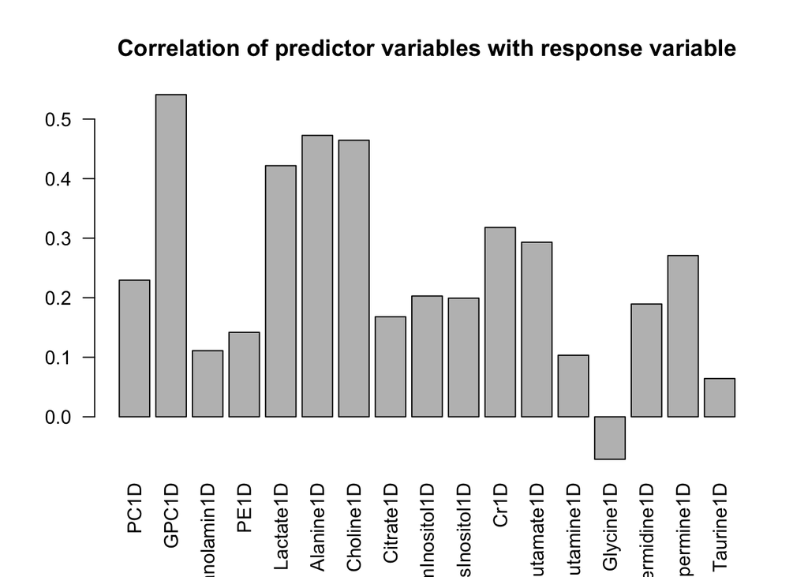

```r
#remove nonnumerical features
data.nt.c.metabolites <- select(data.nt.c, -(ID:gleason_grade))

# make a correlation matrix for all of your predictor variables
# tells us how predictor variables correlate with your outcome as well as how they correlate with each other and point out multicollinearity
correlation = cor(data.nt.c.metabolites)
par(mfrow = c(1,1))
barplot(correlation[18,-c(18)], main = "Correlation of predictor variables with response variable", las = 2)
```

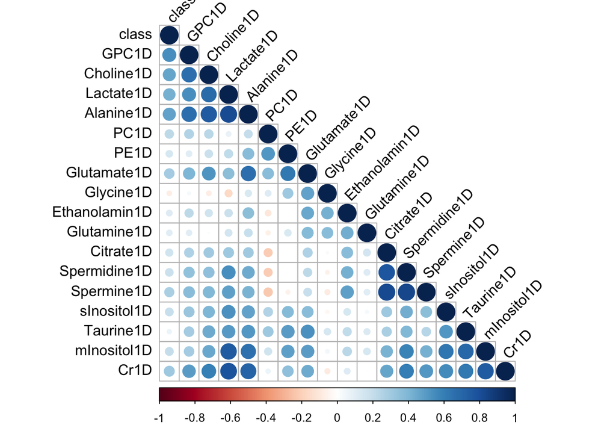

```r
#plot correlation matrix
corrplot(correlation, type="lower", order="hclust", tl.col="black", tl.srt=45)
```

### Prediction using k-Nearest Neighbors

We will perform prediction of malignancy using k-Nearest Neighbors (k-NN). In brief, k-NN performs prediction by minimiznig the distance between samples. This is a supervised algorithm which requires a labeled test set. Before using kNN for prediction, the optimal number of nearest neighbors, or “k”, will be determined using a 10-fold cross validation. This method splits the training dataset into 10 groups of equal size. One group is subsetted to “test” the model while the other k-1 groups are used to “train” the model. This is then repeated 10 times. Here, functions for cross-validation and prediction using k-NN were written using base R.

```r
# knn function written using base R
knnk <- function(klist,Xtrain,Ytrain,Xtest) {
  # k-nearest neighbors classification
  #
  # klist is a list of values of k to be tested
  # Xtrain, Ytrain: the training set
  # Xtest: the test set
  # Output: a matrix of predictions for the test set (one column for each k in klist)

  # Number of training and test examples
  n.train <- nrow(Xtrain)
  n.test <- nrow(Xtest)

  # Matrix to store predictions
  p.test <- matrix(NA, n.test, length(klist))

  # Vector to store the distances of a point to the training points
  dsq <- numeric(n.train)

  # Loop on the test instances
  for (tst in 1:n.test)
  {
    # Compute distances to training instances
    for (trn in 1:n.train)
    {
      dsq[trn] <- sqrt(sum((Xtrain[trn,] - Xtest[tst,])^2)) # Euclidean distance
    }

    # Sort distances from smallest to largest
    ord <- order(dsq)

    # Make prediction using majority vote of the k nearest neighbors
    for (ik in 1:length(klist)) {
      p.test[tst,ik] <- mean(Ytrain[ord[1:klist[ik]]])
      p.test[p.test < 0.5] <- 0 # p.test threshold can be optimized
      p.test[p.test > 0.5] <- 1 # p.test threshold can be optimized
    }
  }

  # Return the matrix of predictions
  invisible(p.test)
}

knnk.cv <- function(klist,Xtrain,Ytrain,nfolds) {
  # Cross-validation for kNN
  #
  # Perform nfolds-cross validation of kNN, for the values of k in klist

  # Number of instances
  n.train <- nrow(Xtrain)

  # Matrix to store predictions
  p.cv <- matrix(NA, n.train, length(klist))

  # Prepare the folds
  s <- split(sample(n.train),rep(1:nfolds,length=n.train))

  # Cross-validation
  for (i in seq(nfolds)) {
    p.cv[s[[i]],] <- knnk(klist,Xtrain[-s[[i]],], Ytrain[-s[[i]]], Xtrain[s[[i]],])
  }

  # Return matrix of CV predictions
  invisible(p.cv)
}
```

First, we will split our dataset into train and test sets using `sample_frac`.

```r
# split using dplyr
train <- data.nt.c %>% sample_frac(.70)
test  <- anti_join(data.nt.c, train, by = 'ID')

Xtrain <- select(train, contains("1D"))
Xtest <- select(test, contains("1D"))

Ytrain <- train$class
Ytest <- test$class
```

Now perform a 10-Fold Cross Validation using `kNNk.cv` on the train dataset.

```r
#Make predictions by kNN
klist = c(1:9) # we test all values of k
nfolds = 10 # we make 10-fold cross-validation
predicted.cv = knnk.cv(klist,Xtrain,Ytrain,nfolds)

#Compute misclassification error as a function of k
MCerror = rep(NA,ncol(predicted.cv))
for (i in 1:ncol(predicted.cv)) {
  MCerror[i] <- 1-sum(predicted.cv[,i]==Ytrain)/length(Ytrain)
}
MCerror
```

```
## [1] 0.2444444 0.3851852 0.2222222 0.3629630 0.2740741 0.3333333 0.2814815
## [8] 0.3407407 0.2888889
```

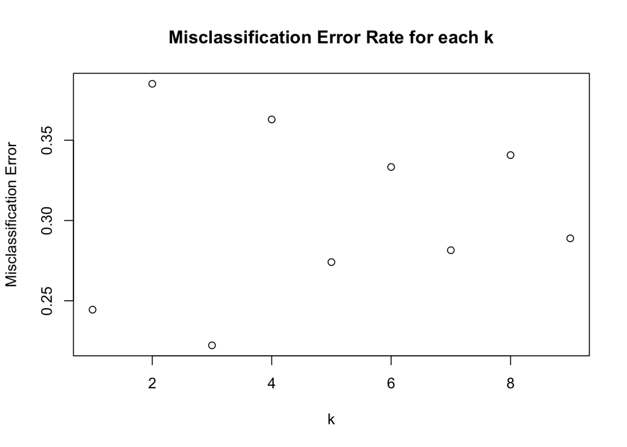

```r
# Plot misclassification error as a function of k
plot(klist, MCerror, main="Misclassification Error Rate for each k", xlab="k", ylab="Misclassification Error")
```

```r
# Use k with lowest misclassification error
final.k = which.min(MCerror)
final.k
```

```
## [1] 3
```

Now let’s test our model using the test dataset.

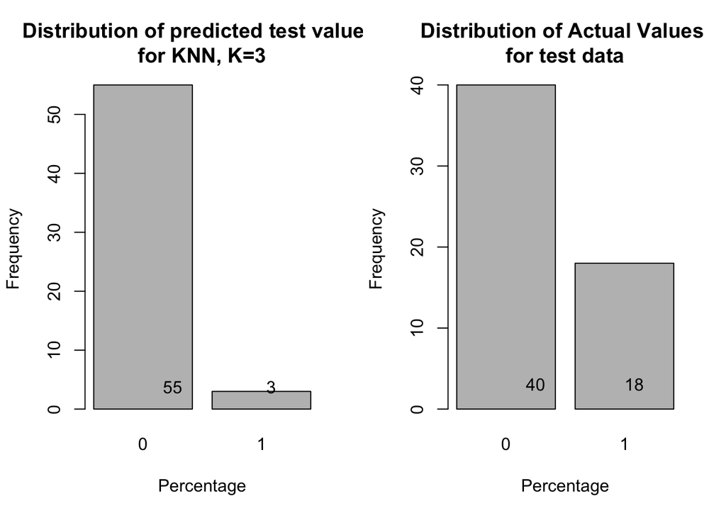

```r
predicted.test = knnk(final.k,Xtrain,Ytrain,Xtest)

#histogram of dist. of scores
PredValues = c(sum(predicted.test == 0), sum(predicted.test == 1))
TrueValues =c(sum(Ytest == 0), sum(Ytest == 1))

par(mfrow= c(1,2))
predicted.testfactor <- as.factor(predicted.test)
plot(predicted.testfactor, main = "Distribution of predicted test values \nfor KNN, K=3", xlab = "Percentage", ylab = "Frequency")
text(predicted.testfactor, labels = PredValues, pos = 3)
Ytestfactor <- as.factor(Ytest)
plot(Ytestfactor, main = "Distribution of Actual Values \nfor test data", xlab = "Percentage", ylab = "Frequency")
text(Ytestfactor, labels = TrueValues, pos = 3)
```

Determine model performance by determining the accuracy, sensitivity, and specificity using `confusionMatrix`.

```r
library(caret)
Ytest <- as.factor(Ytest)
confusionMatrix(predicted.testfactor, Ytest, positive='1')
```

```
## Confusion Matrix and Statistics
##
##           Reference
## Prediction  0  1
##          0 39 16
##          1  1  2
##
##                Accuracy : 0.7069
##                  95% CI : (0.5727, 0.8191)
##     No Information Rate : 0.6897
##     P-Value [Acc > NIR] : 0.450692
##
##                   Kappa : 0.1117
##
##  Mcnemar's Test P-Value : 0.000685
##
##             Sensitivity : 0.11111
##             Specificity : 0.97500
##          Pos Pred Value : 0.66667
##          Neg Pred Value : 0.70909
##              Prevalence : 0.31034
##          Detection Rate : 0.03448
##    Detection Prevalence : 0.05172
##       Balanced Accuracy : 0.54306
##
##        'Positive' Class : 1
##
```